# Machine Learning 1

Barry (PID: 911)

10/21/2021

First up is clustering methods

# Kmeans clustering

The function in base R to do Kmeans clustering is called `kmeans()`.

First make up some data where we know what the answer should be:

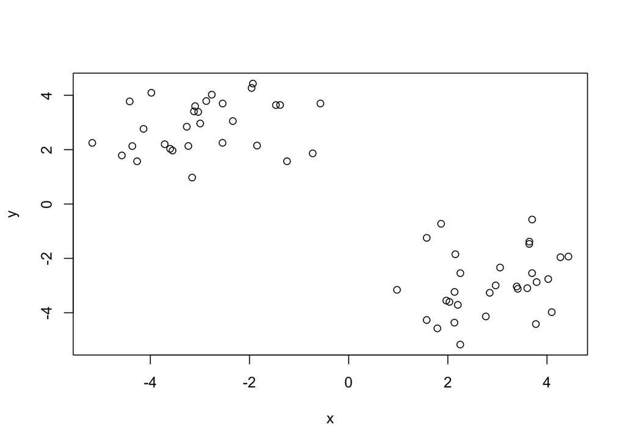

```r
tmp <- c(rnorm(30,-3), rnorm(30,3))
x <- cbind(x=tmp, y=rev(tmp))
plot(x)
```

> Q. Can we use kmeans() to cluster this data setting k to 2 and nstart to 20?

```r
km <- kmeans(x, centers = 2, nstart=20)
km
```

```
## K-means clustering with 2 clusters of sizes 30, 30
##
## Cluster means:
##           x         y
## 1  2.866737 -2.928501
## 2 -2.928501  2.866737
##
## Clustering vector:
##  [1] 2 2 2 2 2 2 2 2 2 2 2 2 2 2 2 2 2 2 2 2 2 2 2 2 2 2 2 2 2 2 1 1 1 1 1 1 1 1
## [39] 1 1 1 1 1 1 1 1 1 1 1 1 1 1 1 1 1 1 1 1 1 1
##
## Within cluster sum of squares by cluster:
## [1] 65.80807 65.80807
##  (between_SS / total_SS =  88.4 %)
##
## Available components:
##
## [1] "cluster"      "centers"      "totss"        "withinss"     "tot.withinss"
## [6] "betweenss"    "size"         "iter"         "ifault"
```

> Q. How many points are in each cluster?

```r
km$size
```

```
## [1] 30 30
```

> Q. What ‘component’ of your result object details cluster assignment/membership?

```r
km$cluster
```

```
##  [1] 2 2 2 2 2 2 2 2 2 2 2 2 2 2 2 2 2 2 2 2 2 2 2 2 2 2 2 2 2 2 1 1 1 1 1 1 1 1
## [39] 1 1 1 1 1 1 1 1 1 1 1 1 1 1 1 1 1 1 1 1 1 1
```

> Q. What ‘component’ of your result object details cluster center?

```r
km$centers
```

```
##           x         y
## 1  2.866737 -2.928501
## 2 -2.928501  2.866737
```

> Q. Plot x colored by the kmeans cluster assignment and add cluster centers as blue points

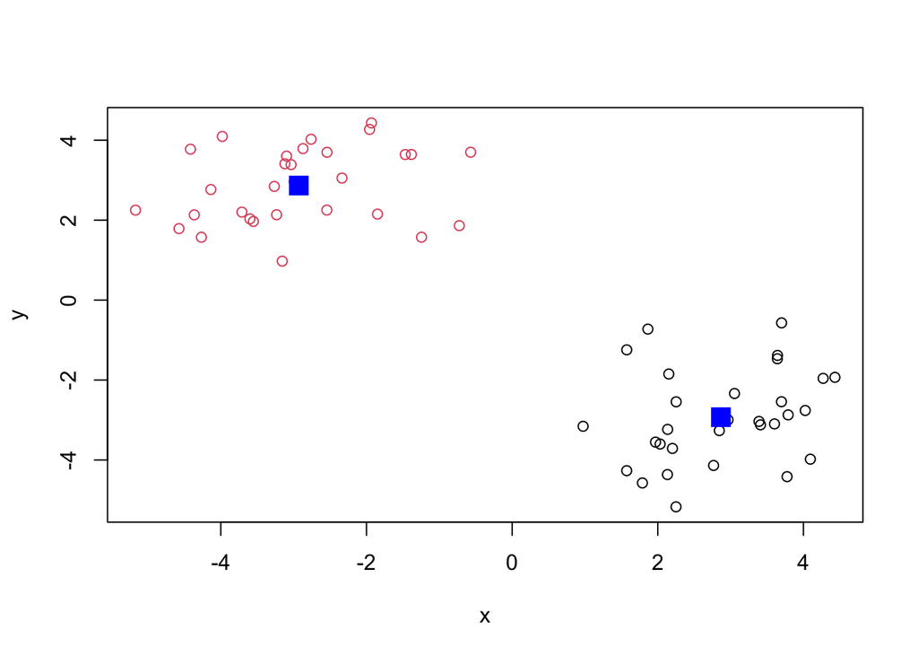

```r
plot(x, col=km$cluster)
points(km$centers, col="blue", pch=15, cex=2)
```

# Hierarchical Clustering

A big limitation with k-means is that we have to tell it K (the number of clusters we want).

Analyze this same data with hclust()

Demonstrate the use of dist(), hclust(), plot() and cutree() functions to do clustering, Generate dendrograms and return cluster assignment/ membership vector…

```r
hc <- hclust( dist(x) )
hc
```

```
##
## Call:
## hclust(d = dist(x))
##
## Cluster method   : complete
## Distance         : euclidean
## Number of objects: 60
```

There is a plot method for hclust result objects. Let’s see it.

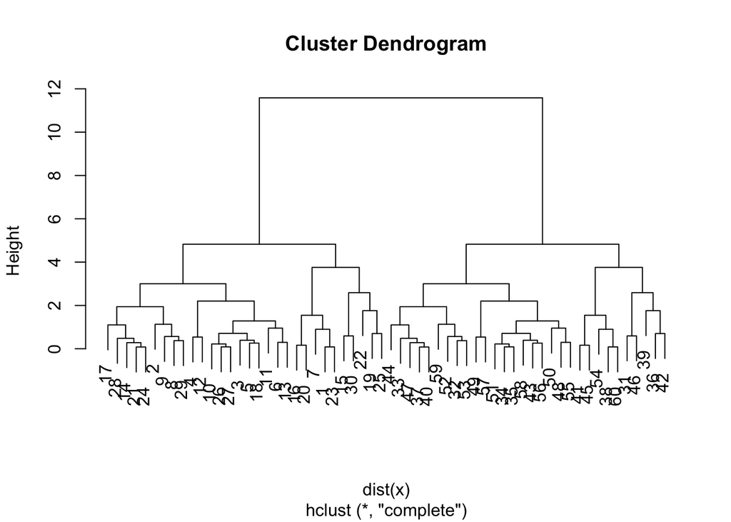

```r
plot(hc)
```

To get our cluster membership vector we have to do a wee bit more work. We have to “cut” the tree where we think it makes sense. For this we use the `cutree()` function.

```r
cutree(hc, h=6)
```

```
##  [1] 1 1 1 1 1 1 1 1 1 1 1 1 1 1 1 1 1 1 1 1 1 1 1 1 1 1 1 1 1 1 2 2 2 2 2 2 2 2
## [39] 2 2 2 2 2 2 2 2 2 2 2 2 2 2 2 2 2 2 2 2 2 2
```

You can also call `cutree()` setting k=the number of grps/clusters you want.

```r
grps <- cutree(hc, k=2)
```

Make our results plot

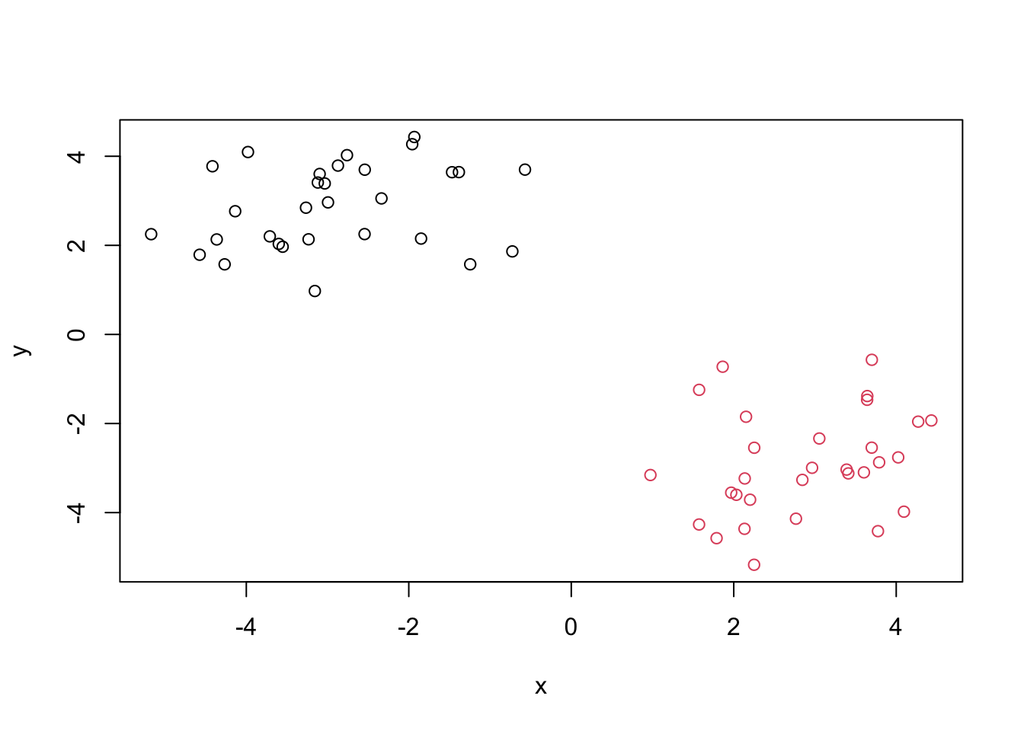

```r
plot(x, col=grps)
```